# Automating our work away

## Outline

### 1. About Darkhorse Analytics

### 2. Problems we faced

### 3. How we solved those problems

### 4. How you can improve R(Markdown) adoption

[figure not shown]

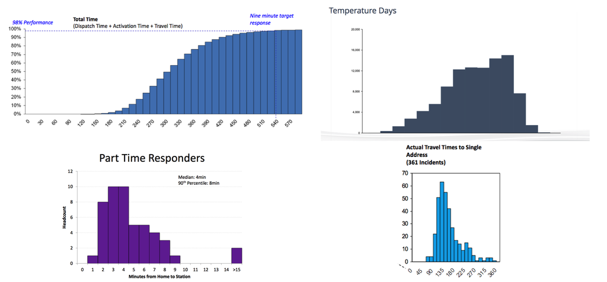

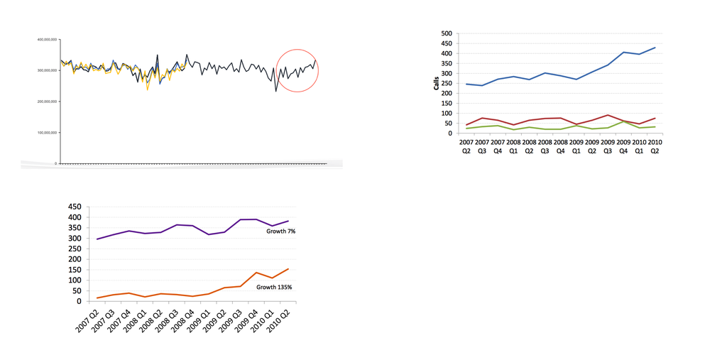

## Problems

## Problems

1. It takes a lot of time to replicate, which is a problem when rework happens (>50 slides!). We've had 3 month projects with 1 month consumed by rework.

## Problems

1. It takes a lot of time to replicate, which is a problem when rework happens (>50 slides!). We've had 3 month projects with 1 month consumed by rework.
2. All styled differently. We need to edit every plot individually.

## Problems

1. It takes a lot of time to replicate, which is a problem when rework happens (>50 slides!). We've had 3 month projects with 1 month consumed by rework.
2. All styled differently. We need to edit every plot individually.
3. No documentation on how to replicate.

## Instead? R!

## What we did:

## What we did:

1. Use RMarkdown to write template ("best practice") slides.

## What we did:

1. Use RMarkdown to write template ("best practice") slides.
2. Made the slides accessible to the company (we used Git + Bitbucket).

## What we did:

1. Use RMarkdown to write template ("best practice") slides.
2. Made the slides accessible to the company (we used Git + Bitbucket).
3. Made it easy to run in other environments (we used installation scripts; moving to Docker)

## What we did:

1. Use RMarkdown to write template ("best practice") slides.
2. Made the slides accessible to the company (we used Git + Bitbucket).
3. Made it easy to run in other environments (we used installation scripts; moving to Docker)
4. Iterate (we used Git).

## What we did:

1. Use RMarkdown to write template ("best practice") slides.
2. Made the slides accessible to the company (we used Git + Bitbucket)
3. Made it easy to run in other environments (we used installation scripts; moving to Docker)
4. Iterate (we used Git).
5. Publish as a package (yet to happen).

## R:

```
darkhorse_histogram = function(df, x_var, x_breaks, x_label,
                               y_var, y_breaks, y_label,
                               title, col="#E69F00") {
    ggplot(df, aes_string(x = x_var, y = y_var)) +
        geom_bar(fill=col, stat = "identity") +
        geom_hline(yintercept= 0, colour=col) +
        darkhorse_theme() +
        ggtitle(title) +
        theme(axis.line.x = element_blank(),
            axis.line.y = element_blank(),
            axis.ticks = element_blank()) +
        ylab(y_label) + xlab(x_label) +
        scale_y_continuous(breaks=y_breaks) +
        geom_hline(yintercept=y_breaks[2:length(y_breaks)], color="white") +
        scale_x_continuous(breaks=x_breaks)
}
```

## Go from…

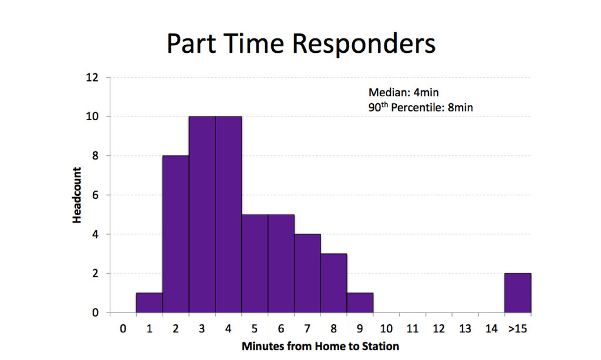

## To…

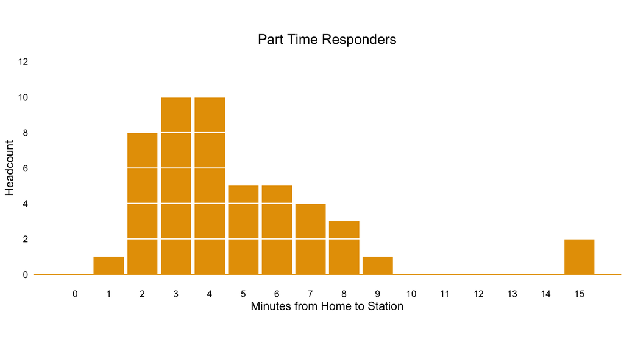

## Also: SQL

```
SELECT
  *
FROM (SELECT
  CASE
    WHEN Call_Type NOT IN ('Medical', 'Fire', 'Fire Alarm Ringing', 'Vehicle Incident') THEN 'Other'
    ELSE Call_Type
  END AS CallType,
  CallID,
  Year
FROM ERA_TFS.dbo.Calls_Template
WHERE Qualified_Event = 1) t
PIVOT (COUNT(CallID) FOR Year IN ([2012], [2013], [2014])) pvt
```

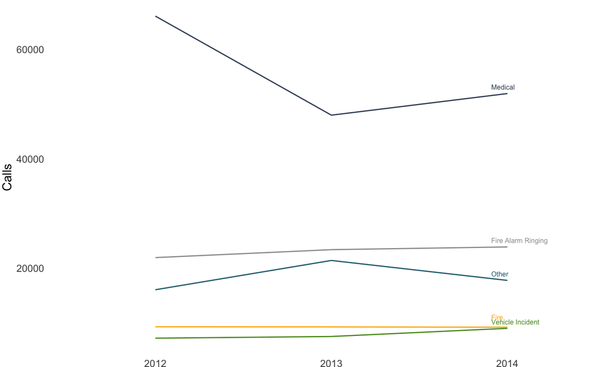

## Lessons

### 1. Make it great.

## Lessons

### 1. Make it great.

### 2. Make it easy.

## Lessons

### 1. Make it great.

### 2. Make it easy.

### 3. Make it profitable.